# Forecasting football injuries by combining screening, monitoring and machine learning - 1/ 2 Data preparation and feature engineering

Anne Hecksteden & Georges Pierre Schmartz

21 March 2022

# Read Me

This R Markdown document provides reproducible code for data handling and feature engineering - leading from raw data to the dataset used for machine learning. The machine learning algorithm itself as well as some accompanying descriptives are presented in a second document.

Important note: The densely commented code presented here aims at transparency and accessibility - not at efficiency of coding and computation.

Please note that providing raw data is not possible due to the challenge of effective anonymization in professional football and lack of consent.

# Loading raw data

```r
# Clean workspace (if necessary)
rm(list = ls())
ggplot_theme<-theme_bw()

# Load raw data
load("Raw_data.RData")
data <- Raw_data
```

# Generating utility variables

## Days since study start

Study start was June first 2019

```r
data$Day_in_study <-difftime(data$Date, min(data$Date), units="days")
data$Day_in_study <- data$Day_in_study + 1
data$Day_in_study <- as.integer(data$Day_in_study)
```

## Dichotomous classification of injury status

In raw data, injury status has 3 levels: fully available for training and matchplay; day of injury; and rehab (injury until return to play). Here the dichotomous variable “Unfit” is generated: FALSE = fully available for training and matchplay; TRUE = day of injury or rehab (until return to play))

```r
# Create Variable fit (fully available) vs. unfit (injury and rehab)
data$Unfit<-data$Inj_status!=0
data$Unfit <- as.logical(data$Unfit)
```

# Generating criterion and features for machine learning

## Criterion

Injury_status = 1 includes the onset of all sorts of bodily complaints that have been reported by the players. However, only acute, non-contact, time-loss injuries are of interest here. Therefore a criterion variable “Crit” is generated.

### Precheck “Injury_status”

Number of occurrences (player-days) per level of injury_status and check for missing values Labels: uninjured / normal availability; day of injury; rehab (injury to return-to-play)

```r
data$Inj_status <- factor(data$Inj_status,levels = 0:2,labels = c("Available","Injury","Rehab"))
table(data$Inj_status)
```

```
##
## Available    Injury     Rehab
##     16314       109      1031
```

```r
any(is.na(data$Inj_status))
```

```
## [1] FALSE
```

As expected the dataset is imbalanced. There are no missing values for injury_status.

### Precheck “Reason”

Acute vs. chronic (overload) injuries

```r
table(data$Reason)
```

```
##
##   Acute Chronic
##     101       8
```

### Precheck “Injury mechanism”

Contact vs. Non-contact injuries

```r
data$Injury_mechanism <- factor(data$Injury_mechanism,levels = 0:1,labels = c("contact","non-contact"))
table(data$Injury_mechanism)
```

```
##
##     contact non-contact
##          40          63
```

```r
any(is.na(data$Injury_mechanism))
```

```
## [1] TRUE
```

### Generate identifier for criterion injuries “Crit”

Crit: Criterion = Day of acute, non-contact, time-loss injury (Binary: TRUE / FALSE)

```r
data$Crit <- data$Inj_status == "Injury" & data$Injury_mechanism == "non-contact" & data$Days_off > 0 & data$Reason == "Acute"
data$Crit<-ifelse(!is.na(data$Crit),data$Crit,F)
data$Crit <- as.logical(data$Crit)
```

### Postcheck

Number of criterion injuries and check for missing values in Crit

```r
table(data$Crit)
```

```
##
## FALSE  TRUE
## 17402    52
```

```r
any(is.na(data$Crit))
```

```
## [1] FALSE
```

52 criterion-injuries have been recorded. There are no missing values.

## Utility variable derived from Crit: Players who sustain a criterion injury vs. players who do not (“victims”)

This utility variably will later be needed for optimal splitting of the dataset into a training and a test set.

```r
# Identify "victims"
data_victim <- filter(data, Crit)
# Create variable "Victim"
data$Victim<-data$ID%in%data_victim$ID
data$Victim <- as.logical(data$Victim)

table(data$Victim, data$Crit)
```

```
##
##         FALSE TRUE
##   FALSE  8864    0
##   TRUE   8538   52
```

## Identify time-loss injuries for epidemiological description

Generate a variable identifying time_loss injuries (“TL_injury”) as recommended for general epidemiological description.

```r
data$TL_injury <-  data$Inj_status == "Injury" & data$Days_off > 0
data$TL_injury <- as.logical(data$TL_injury)

table(data$TL_injury)
```

```
##
## FALSE  TRUE
## 17357    97
```

```r
any(is.na(data$TL_injury))
```

```
## [1] FALSE
```

## Explanatory features

### Basic player information

Please note: The plots serve primarily as plausibility check and therefor visualize the distribution on the level of datapoints (not players).

#### Age

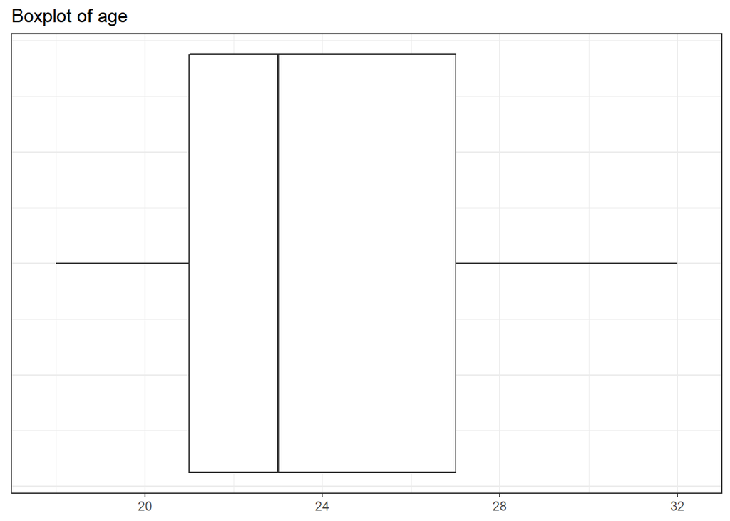

```r
ggplot(data, aes(x=Age,y=3)) + geom_boxplot()+ ggtitle("Boxplot of age") + xlab("age [years]")+scale_x_continuous(expand = c(0,1))+
  ggplot_theme+theme(
    axis.text.y = element_blank(),
    axis.ticks.y =  element_blank(),
    axis.title =   element_blank()
                     )
```

```r
any(is.na(data$Age))
```

```
## [1] FALSE
```

The age of players is consistent with professional soccer. There are no outliers and no missing values.

#### Playing position

Labels: 0=Goalkeeper, 1=Defender, 2=Midfielder, 3=Striker Note: The counts are for the number of datapoints (not individual players).

```r
data$Pos_code<-factor(data$Pos_code,levels = 0:3,labels = c("Goalkeeper","Defender","Midfielder","Striker"))

table(data$Pos_code)
```

```
##
## Goalkeeper   Defender Midfielder    Striker
##       2408       4816       6948       3282
```

```r
any(is.na(data$Pos_code))
```

```
## [1] FALSE
```

Plausible and without missing values

#### History of previous injuries

Here the current number of days lost due to injury is calculated from the baseline value (injuries prior to the study) and injuries during the study period but previous to the day in question.

```r
# Define funktion for trailing sum of "Unfit = 1"
trailing_sum <- function(df){
  df$trailing_sum_inj <- runner(x = as.vector(df$Unfit), f = function(x) sum(x, na.rm = TRUE), k = 365, lag = 1)
  return(df)
}


#Split the dataset according to ID
data_split <- split(data, data$ID)

# Apply the function
data_split <- lapply(data_split, trailing_sum)

# Unlist back to one dataframe
data <- ldply(data_split, data.frame)


# Calculate current days lost to injury (trailing_sum plus baseline)
data$VV_days_c <- data$VV_days_BL + data$trailing_sum_inj

s2 <- summarize(data, Injured_BL_mean = mean(VV_days_BL), Injured_BL_SD = sd(VV_days_BL), Injured_current_mean = mean(VV_days_c), Injured_current_SD = sd(VV_days_c))

any_na <- any(is.na(data$VV_days_c))
s4 <- cbind(s2, any_na)

kable(s4, caption = "rmd-table 2: Days lost to injury - baseline vs. current", digits = 0, align = "c")
```

rmd-table 2: Days lost to injury - baseline vs. current

| Injured_BL_mean | Injured_BL_SD | Injured_current_mean | Injured_current_SD | any_na |
| --- | --- | --- | --- | --- |
| 156 | 202 | 162 | 202 | FALSE |

##### Adjusting days lost to injury for age

Higher age means more cumulative exposure that is more opportunity to get injured. By adjusting for age, the feature rather reflects individual susceptibility for injury.

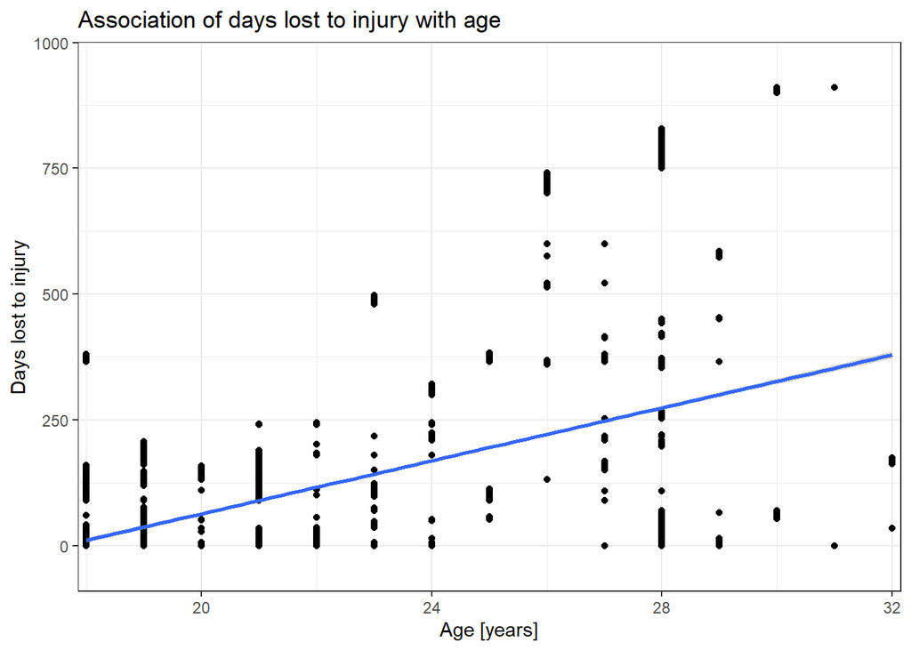

```r
ggplot(data, aes(x=Age, y=VV_days_c)) + geom_point() + geom_smooth(method = "lm") + ggtitle("Association of days lost to injury with age") + ylab("Days lost to injury") + xlab("Age [years]")+ggplot_theme+scale_x_continuous(expand = c(0.01,0.01))+scale_y_continuous(expand = c(0.1,0.1))
```

```r
model_age <- lm(VV_days_c ~ Age, data = data)
summary(model_age)
```

```
##
## Call:
## lm(formula = VV_days_c ~ Age, data = data)
##
## Residuals:
##     Min      1Q  Median      3Q     Max
## -353.04 -109.13  -30.75   79.16  583.28
##
## Coefficients:
##              Estimate Std. Error t value Pr(>|t|)
## (Intercept) -462.9865     9.1804  -50.43   <2e-16 ***
## Age           26.3234     0.3824   68.84   <2e-16 ***
## ---
## Signif. codes:  0 '***' 0.001 '**' 0.01 '*' 0.05 '.' 0.1 ' ' 1
##
## Residual standard error: 179.5 on 17452 degrees of freedom
## Multiple R-squared:  0.2136, Adjusted R-squared:  0.2135
## F-statistic:  4739 on 1 and 17452 DF,  p-value: < 2.2e-16
```

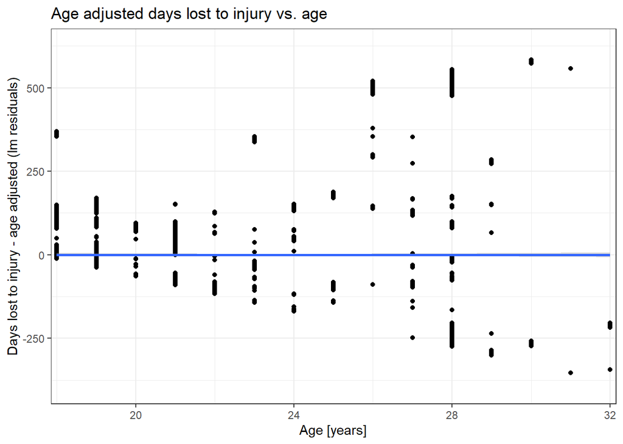

```r
data$VV_resid_age <- resid(model_age)

ggplot(data, aes(x=Age, y=VV_resid_age)) +
  geom_point() + geom_smooth(method = "lm") +
  ggtitle("Age adjusted days lost to injury vs. age") +
  ylab("Days lost to injury - age adjusted (lm residuals)") +
  xlab("Age [years]")+
  ggplot_theme+
  scale_x_continuous(expand = c(0.01,0.01))+
  scale_y_continuous(expand = c(0.1,0.1))
```

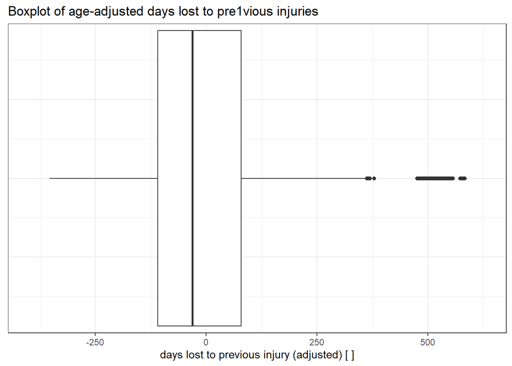

```r
ggplot(data, aes(x=VV_resid_age)) + geom_boxplot() + ggtitle("Boxplot of age-adjusted days lost to pre1vious injuries") + xlab("days lost to previous injury (adjusted) [ ]")+ggplot_theme+
  scale_x_continuous(expand = c(0.1, 0.1))+
  scale_y_continuous(expand = c(0.01,0.01))+
  theme(
    axis.ticks.y = element_blank(),
    axis.text.y = element_blank(),
        )
```

```r
any(is.na(data$VV_resid_age))
```

```
## [1] FALSE
```

### Screening

#### Imputing missing values

Some players have missed parts of one of the two screening tests. In this case the values from the other screening test are used to fill in the missing values.

##### Checking for missing values in raw screening data

```r
na_Fat <- sum(is.na(data$Fat))
na_IAT <- sum(is.na(data$IAT))
na_Sprint <- sum(is.na(data$Sprint_30))
na_SIMS_Score <- sum(is.na(data$SIMS_score))
na_SIMS_Pain <- sum(is.na(data$SIMS_pain))

na_Screening <- cbind(na_Fat, na_IAT, na_Sprint, na_SIMS_Score, na_SIMS_Pain)

kable(na_Screening, caption = "Missing raw values in screening variables", digits = 0, align = "c")
```

Missing raw values in screening variables

| na_Fat | na_IAT | na_Sprint | na_SIMS_Score | na_SIMS_Pain |
| --- | --- | --- | --- | --- |
| 2264 | 1706 | 174 | 0 | 0 |

##### Filling in values from the other test if available

```r
# For Fat
data <- ddply(data,
      .(ID),
      transform,
      Fat=ifelse(is.na(Fat), median(Fat, na.rm=TRUE), Fat))


# For IAT
data <- ddply(data,
                  .(ID),
                  transform,
                  IAT=ifelse(is.na(IAT), median(IAT, na.rm=TRUE), IAT))

# For Sprint_30

data <- ddply(data,
                  .(ID),
                  transform,
                  Sprint_30=ifelse(is.na(Sprint_30), median(Sprint_30, na.rm=TRUE), Sprint_30))
```

##### Checking for remaining missing values

```r
na_Fat <- sum(is.na(data$Fat))
na_IAT <- sum(is.na(data$IAT))
na_Sprint <- sum(is.na(data$Sprint_30))
na_SIMS_Score <- sum(is.na(data$SIMS_score))
na_SIMS_Pain <- sum(is.na(data$SIMS_pain))

na_Screening <- cbind(na_Fat, na_IAT, na_Sprint, na_SIMS_Score, na_SIMS_Pain)

kable(na_Screening, caption = "Missing values in screening variables after filling up values from other test", digits = 0, align = "c")
```

Missing values in screening variables after filling up values from other test

| na_Fat | na_IAT | na_Sprint | na_SIMS_Score | na_SIMS_Pain |
| --- | --- | --- | --- | --- |
| 236 | 236 | 25 | 0 | 0 |

##### Removing players with remaining missing values

Three players who never provided data for at least one screening test are excluded. There remain 88 players.

```r
length(unique(data$ID))
```

```
## [1] 91
```

```r
data <- subset(data, !is.na(Fat))

length(unique(data$ID))
```

```
## [1] 88
```

##### Final check for completeness of screening data

```r
na_Fat <- sum(is.na(data$Fat))
na_IAT <- sum(is.na(data$IAT))
na_Sprint <- sum(is.na(data$Sprint_30))
na_SIMS_Score <- sum(is.na(data$SIMS_score))
na_SIMS_Pain <- sum(is.na(data$SIMS_pain))

na_Screening <- cbind(na_Fat, na_IAT, na_Sprint, na_SIMS_Score, na_SIMS_Pain)

kable(na_Screening, caption = "Final check for completeness of screening data", digits = 0, align = "c")
```

Final check for completeness of screening data

| na_Fat | na_IAT | na_Sprint | na_SIMS_Score | na_SIMS_Pain |
| --- | --- | --- | --- | --- |
| 0 | 0 | 0 | 0 | 0 |

#### Check distribution of screening features

##### Body fat percentage

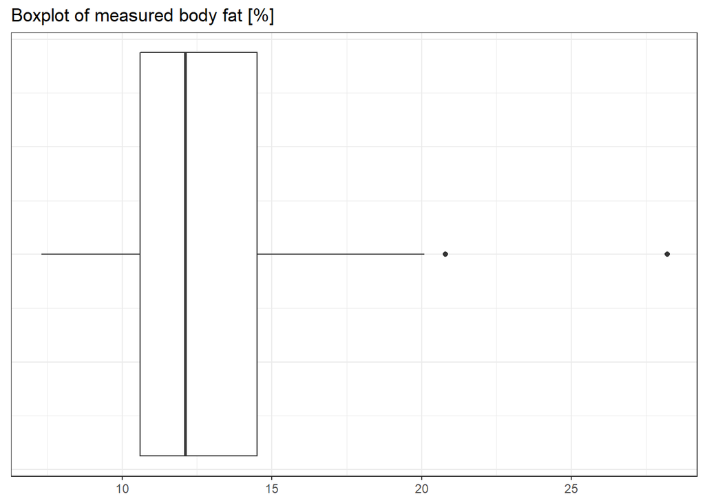

```r
ggplot(data, aes(x=Fat)) + geom_boxplot() + ggtitle("Boxplot of measured body fat [%]") + xlab("Body fat [%]")+scale_x_continuous(expand = c(0,1))+
  ggplot_theme+theme(
    axis.text.y = element_blank(),
    axis.ticks.y =  element_blank(),
    axis.title =   element_blank()
                     )
```

##### Individual anaerobic threshold

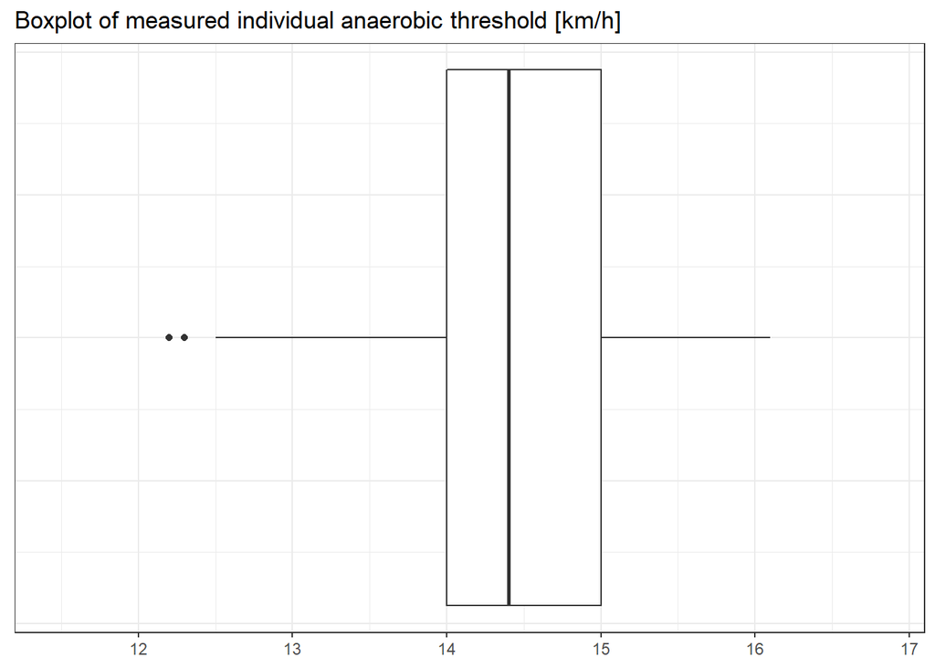

```r
ggplot(data, aes(x=IAT)) + geom_boxplot() + ggtitle("Boxplot of measured individual anaerobic threshold [km/h]") + xlab("IAT [km/h]")+scale_x_continuous(expand = c(0,1))+
  ggplot_theme+theme(
    axis.text.y = element_blank(),
    axis.ticks.y =  element_blank(),
    axis.title =   element_blank()
                     )
```

##### 30 m linear sprint time

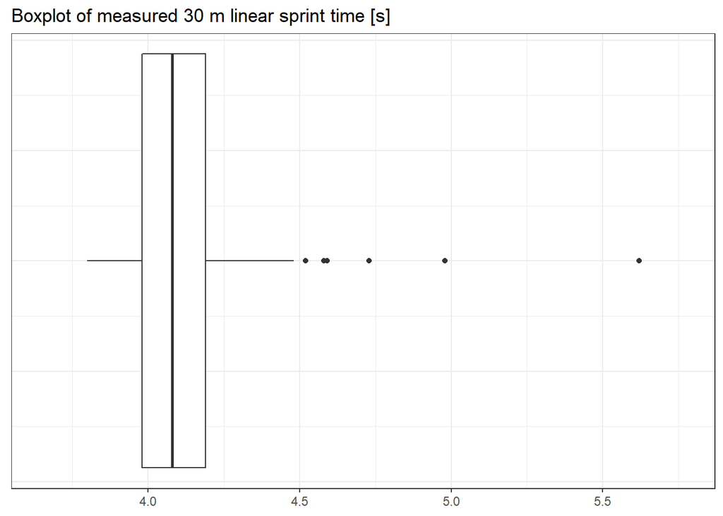

```r
ggplot(data, aes(x=Sprint_30)) + geom_boxplot() + ggtitle("Boxplot of measured 30 m linear sprint time [s]") + xlab("30 m linear sprint time [s]")+scale_x_continuous(expand = c(0,0.25))+
  ggplot_theme+theme(
    axis.text.y = element_blank(),
    axis.ticks.y =  element_blank(),
    axis.title =   element_blank()
                     )
```

##### Soccer Injury Movement Screen - overall score

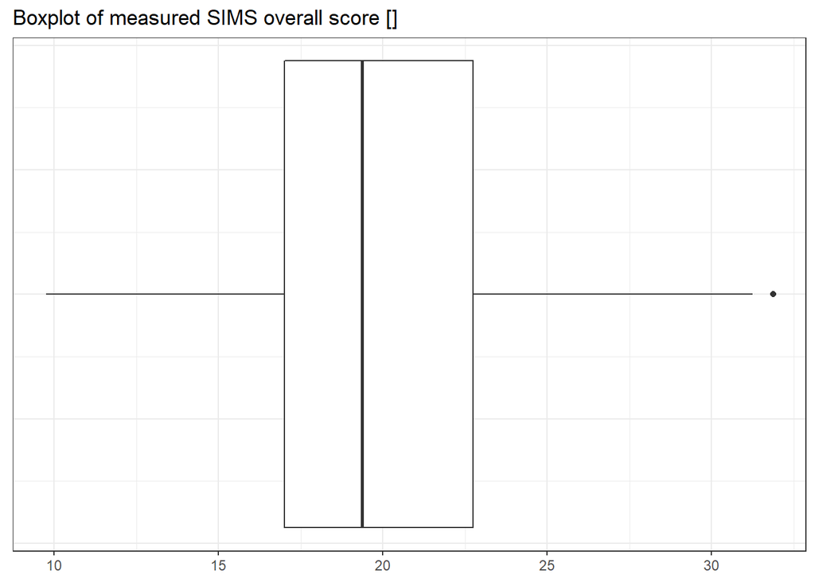

```r
ggplot(data, aes(x=SIMS_score)) + geom_boxplot() + ggtitle("Boxplot of measured SIMS overall score []") + xlab("SIMS overall score")+scale_x_continuous(expand = c(0,1))+
  ggplot_theme+theme(
    axis.text.y = element_blank(),
    axis.ticks.y =  element_blank(),
    axis.title =   element_blank()
                     )
```

#### Soccer Injury Movement Screen - pain in at least one subtest

SIMS_pain is the sum of pain scores in the SIMS subtests. Here we dichotomize into no pain vs. pain in at least one subtest.

```r
data$SIMS_pain <- data$SIMS_pain!="0"

table(data$SIMS_pain)
```

```
##
## FALSE  TRUE
## 16035  1183
```

### Monitoring

#### Internal training load

Three variables regarding internal training load (session RPE method) are taken from the custom App used for data collection.

sRPE = internal training load for the respective day and player (can be sum of several training bouts). If the respective player failed to provide internal training load that day, the team average is already imputed. Of note: The “Source” variable allows tracking whether sRPE has been directly provided by the individual player.

sRPE_avg_7d = linearly weighted, trailing 7 day average of sRPE for the respective player. This variable is used as measure of current training load.

sRPE_team_avg = team average of sRPE values provided that day. This variable is used to gauge the strain imposed by the current day training (exposure). This variable is used as indicator of the stress imposed by the exposure on the day of prediction.

##### Check for missing values

There are no missing values.

```r
na_sRPE <- any(is.na(data$Srpe))
na_avg_7d <- any(is.na(data$Srpe_avg_7d))
na_avg_team <- any(is.na(data$Srpe_team_avg))

na_Load <- cbind(na_sRPE, na_avg_7d, na_avg_team)

kable(na_Load, caption = "Missing values for internal training load", digits = 0, align = "c")
```

Missing values for internal training load

| na_sRPE | na_avg_7d | na_avg_team |
| --- | --- | --- |
| FALSE | FALSE | FALSE |

##### Distribution of daily training loads

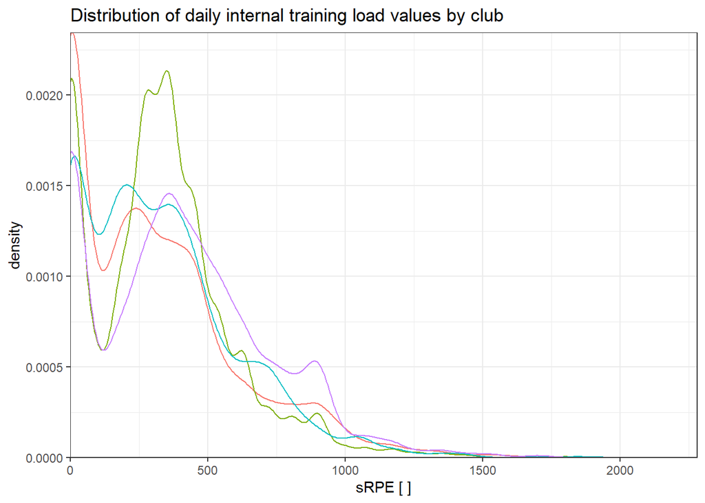

```r
ggplot(data, aes(x=Srpe, color=Club_code)) + geom_density() + ggtitle("Distribution of daily internal training load values by club") + xlab("sRPE [ ]")+scale_x_continuous(expand = c(0,0))+scale_y_continuous(expand = c(0,0))+
  ggplot_theme+guides(color="none")
```

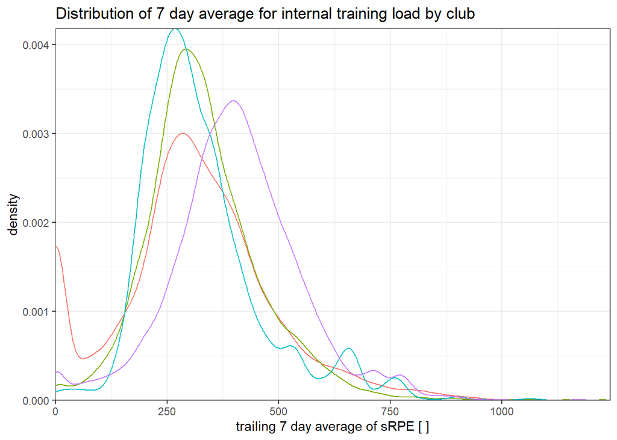

```r
ggplot(data, aes(x=Srpe_avg_7d, color=Club_code)) + geom_density() + ggtitle("Distribution of 7 day average for internal training load by club") + theme(legend.position = "none") + xlab("trailing 7 day average of sRPE [ ]")+scale_x_continuous(expand = c(0,0))+scale_y_continuous(expand = c(0,0))+
  ggplot_theme+guides(color="none")
```

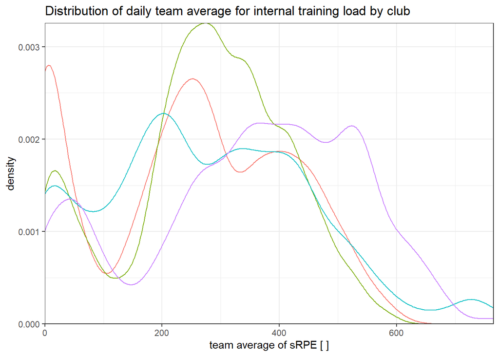

```r
ggplot(data, aes(x=Srpe_team_avg, color=Club_code)) + geom_density() + ggtitle("Distribution of daily team average for internal training load by club") + theme(legend.position = "none") + xlab("team average of sRPE [ ]")+scale_x_continuous(expand = c(0,0))+scale_y_continuous(expand = c(0,0))+
  ggplot_theme+guides(color="none")
```

##### Checking for interindividual variation in the distribution of Srpe

```r
# ID ordered by individual median of Srpe
data_Srpe <- ddply(data, .(ID), summarize,  Srpe_median=median(Srpe))
data_Srpe <- arrange(data_Srpe, Srpe_median)
data_Srpe <- rowid_to_column(data_Srpe)
data_Srpe$ID_Srpe <- data_Srpe$rowid
data_Srpe <- subset(data_Srpe, select = c(ID, ID_Srpe))
data_Srpe$ID_Srpe <- as.factor(data_Srpe$ID_Srpe)

data <- merge(data, data_Srpe)
data$ID_Srpe <- as.factor(data$ID_Srpe)
```

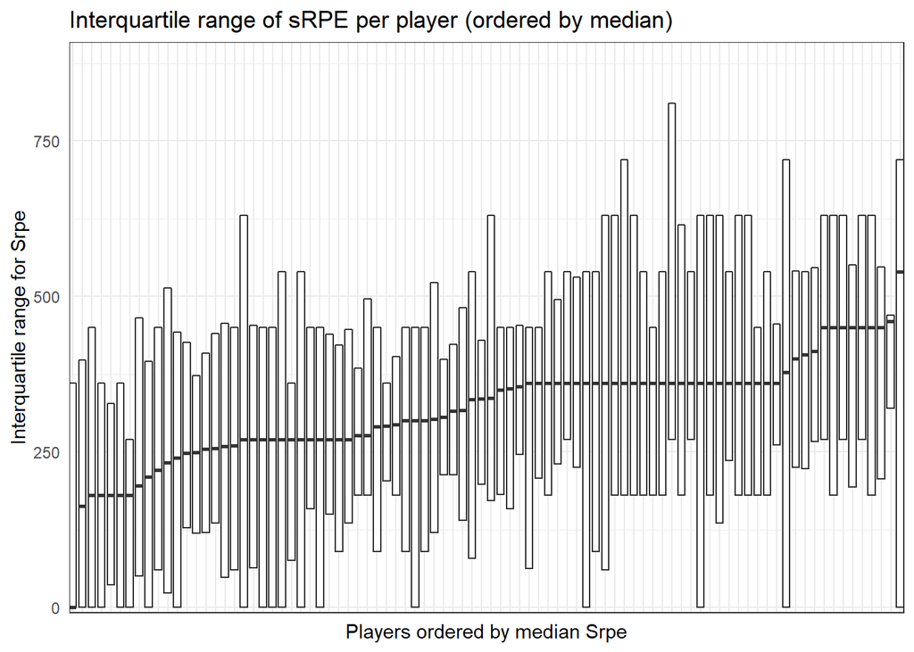

```r
ggplot(data, aes(x=ID_Srpe, y=Srpe)) + geom_boxplot(outlier.shape = NA, coef = 0) + ggtitle("Interquartile range of sRPE per player (ordered by median)") + xlab("Players ordered by median Srpe") + ylab("Interquartile range for Srpe") +ggplot_theme+ theme(axis.ticks = element_blank(), axis.text.x = element_blank()) + coord_cartesian(ylim = c(0,900))+scale_x_discrete(expand = c(0,0))+scale_y_continuous(expand = c(0.01,0))
```

There is considerable interindividual variation in the distribution of Srpe (location as well as spread).

##### Scaling the training load variables

Taking into account the distribution of raw values, interindividual variation (and aiming at methodological consistency) a robust scaling with median and interquartile range is applied on the individual level for all 3 training load variables.

```r
# Define function for robust scaling with median and interquartile range
Srpe_robust_fun <- function(df){
  df$Srpe_robust <- ((df$Srpe - median(df$Srpe)) / IQR(df$Srpe))
  return(df)
}

Srpe_7d_robust_fun <- function(df){
  df$Srpe_7d_robust <- ((df$Srpe_avg_7d - median(df$Srpe_avg_7d)) / IQR(df$Srpe_avg_7d))
  return(df)
}

Srpe_team_robust_fun <- function(df){
  df$Srpe_team_robust <- ((df$Srpe_team_avg - median(df$Srpe_team_avg)) / IQR(df$Srpe_team_avg))
  return(df)
}

# Split the dataset according to ID
data_split <- split(data, data$ID)

#### Apply functions
data_split <- lapply(data_split, Srpe_robust_fun)
data_split <- lapply(data_split, Srpe_7d_robust_fun)
data_split <- lapply(data_split, Srpe_team_robust_fun)


#### Unlist back to one df and merge with data
data <- ldply(data_split, data.frame)
```

##### Check distribution of scaled variables

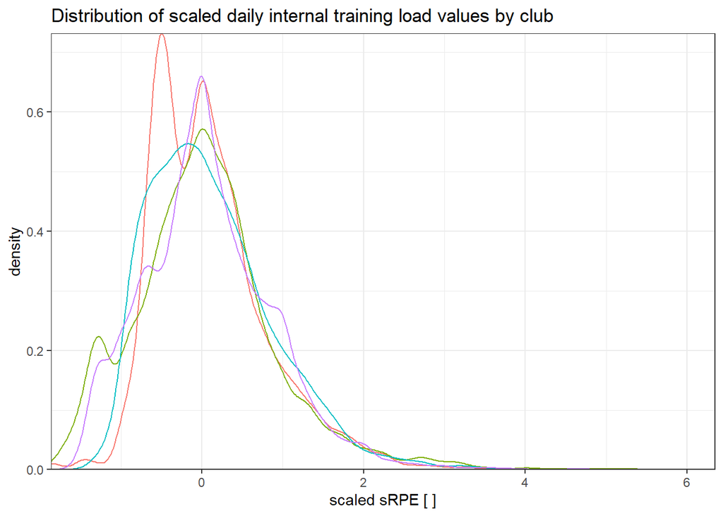

```r
ggplot(data, aes(x=Srpe_robust, color=Club_code)) + geom_density() + ggtitle("Distribution of scaled daily internal training load values by club") + theme(legend.position = "none") + xlab("scaled sRPE [ ]")+scale_x_continuous(expand = c(0,0))+scale_y_continuous(expand = c(0,0))+
  ggplot_theme+guides(color="none")
```

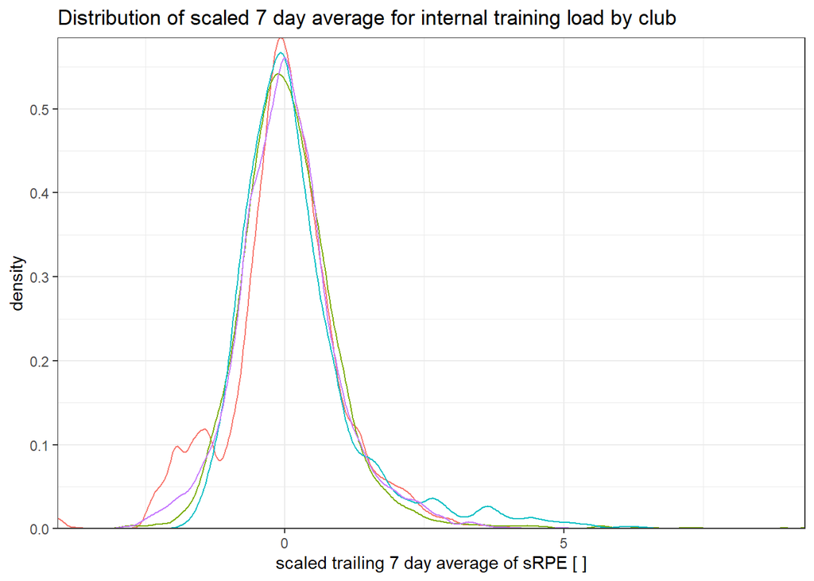

```r
ggplot(data, aes(x=Srpe_7d_robust, color=Club_code)) + geom_density() + ggtitle("Distribution of scaled 7 day average for internal training load by club") + theme(legend.position = "none") + xlab("scaled trailing 7 day average of sRPE [ ]")+scale_x_continuous(expand = c(0,0))+scale_y_continuous(expand = c(0,0))+
  ggplot_theme+guides(color="none")
```

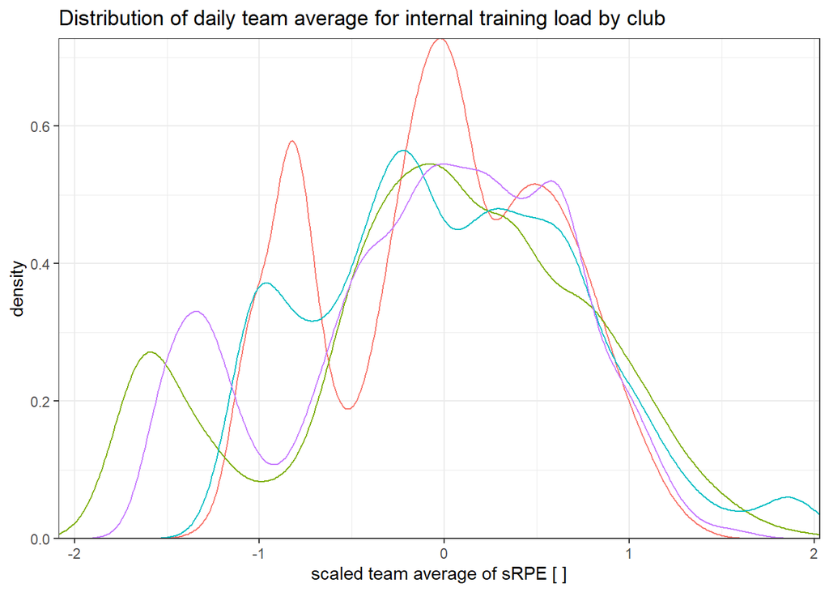

```r
ggplot(data, aes(x=Srpe_team_robust, color=Club_code)) + geom_density() + ggtitle("Distribution of daily team average for internal training load by club") + theme(legend.position = "none") + xlab("scaled team average of sRPE [ ]")+scale_x_continuous(expand = c(0,0))+scale_y_continuous(expand = c(0,0))+
  ggplot_theme+guides(color="none")
```

##### Final check for missing values in scaled training loads

There are no missing values.

```r
na_sRPE <- any(is.na(data$Srpe_robust))
na_avg_7d <- any(is.na(data$Srpe_7d_robust))
na_avg_team <- any(is.na(data$Srpe_team_robust))

na_Load <- cbind(na_sRPE, na_avg_7d, na_avg_team)

kable(na_Load, caption = "Missing values for scaled internal training load", digits = 0, align = "c")
```

Missing values for scaled internal training load

| na_sRPE | na_avg_7d | na_avg_team |
| --- | --- | --- |
| FALSE | FALSE | FALSE |

#### Subjective stress and recovery (questionair data)

#### Selection of dimension and missing values

From the 8 dimensions of the Short Recovery and Stress Scale only “Overall Stress” is used (due to the limited number of criterion injuries). Unfortunately, the number of missing data is considerable.

```r
sum(is.na(data$KEB_AB))
```

```
## [1] 4527
```

##### First line imputation

Imputing team median for the respective day.

```r
# Preserve raw value for later double-check
data$KEB_AB_raw <- data$KEB_AB

# Create variable differentiating original raw values and imputations
data$Source_KEB <- is.na(data$KEB_AB_raw)

# Impute team median for the same day
data <- ddply(data,
                  .(Club_code, Date),
                  transform,
                  KEB_AB=ifelse(is.na(KEB_AB), median(KEB_AB, na.rm=TRUE), KEB_AB))

sum(is.na(data$KEB_AB))
```

```
## [1] 1121
```

There remain a few missing values

#### Second line imputation

Team median of interpolation between the days before and after

```r
# Funktions for previous and next day
trailing_day <- function(df){
  df$KEB_AB_prev <- runner(x = as.vector(df$KEB_AB), f = function(x) sum(x, na.rm = TRUE), k = 1, lag = 1)
  return(df)
}

next_day <- function(df){
  df$KEB_AB_next <- runner(x = as.vector(df$KEB_AB), f = function(x) sum(x, na.rm = TRUE), k = 1, lag = -1)
  return(df)
}

# Split the dataset according to ID
data_split <- split(data, data$ID)

# Apply functions
data_split <- lapply(data_split, trailing_day)
data_split <- lapply(data_split, next_day)


# Unlist back to one df
data <- ldply(data_split, data.frame)


data$KEB_AB_prev <- unlist(data$KEB_AB_prev)
data$KEB_AB_next <- unlist(data$KEB_AB_next)

# Calculate mean of previous and next day
data$KEB_AB_interpol <- (data$KEB_AB_prev + data$KEB_AB_next)/2
data$KEB_AB_interpol <- round(data$KEB_AB_interpol)

# Fill in team median of interpolated value for missing values
data <- ddply(data,
                  .(Club_code, Date),
                  transform,
                  KEB_AB=ifelse(is.na(KEB_AB), median(KEB_AB_interpol, na.rm=TRUE), KEB_AB))

# Check for remaining missing values
any(is.na(data$KEB_AB))
```

```
## [1] FALSE
```

```r
# Check for agreement with raw values
data$check_KEB <- (data$KEB_AB_raw - data$KEB_AB)
data$check_KEB <- as.numeric(data$check_KEB)
count(data$check_KEB > 0)
```

```
##       x  freq
## 1 FALSE 12691
## 2    NA  4527
```

Fine - All missing values have been filled in with the originally present raw values unchanged.

##### Check for interindividual variability in the distribution of KEB_AB

There is considerable interindividual variation in the distribution of KEB_AB (that is: differncees in the habitual use of the scale between players).

```r
# ID ordered by individual median of KEB_AB
data_KEB <- ddply(data, .(ID), summarize,  KEB_median=median(KEB_AB))
data_KEB <- arrange(data_KEB, KEB_median)
data_KEB <- rowid_to_column(data_KEB)
data_KEB$ID_KEB <- data_KEB$rowid
data_KEB <- subset(data_KEB, select = c(ID, ID_KEB))

data <- merge(data, data_KEB)
data$ID_KEB <- as.factor(data$ID_KEB)
```

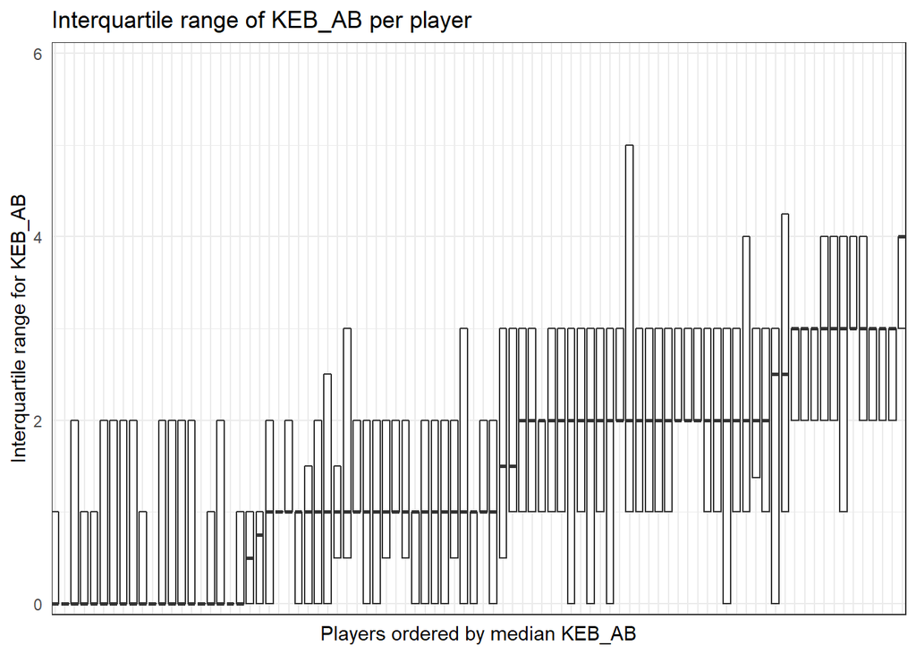

```r
ggplot(data, aes(x=ID_KEB, y=KEB_AB)) + geom_boxplot(outlier.shape = NA, coef = 0) + ggtitle("Interquartile range of KEB_AB per player") + xlab("Players ordered by median KEB_AB") + ylab("Interquartile range for KEB_AB") +ggplot_theme+ theme(axis.ticks = element_blank(), axis.text.x = element_blank())+scale_x_discrete(expand = c(0,0))+scale_y_continuous(expand = c(0.02,0))
```

There is marked interindividual variation in the distribution of KEB (location as well as spread).

##### Robust scaling on the individual level

Aiming at a feature for which a specific value means the same for all individuals, a robust scaling with median and interquartile range is applied on the individual level (same rationale and method as for Srpe).

Practical note: In reality, players who always provide the same value for KEB probably did not take the questionnaire seriously and it may be wiser to use a model without KEB for them. This remains to be tested in future work.

```r
# Define function for robust scaling with median and interquartile range
KEB_AB_robust_fun <- function(df){
  df$KEB_AB_robust <- ((df$KEB_AB - median(df$KEB_AB)) / (IQR(df$KEB_AB)+1))
  return(df)
}


# Split the dataset according to ID
data_split <- split(data, data$ID)

#### Apply function
data_split <- lapply(data_split, KEB_AB_robust_fun)

#### Unlist back to one df and merge with data
data <- ldply(data_split, data.frame)
```

##### Check for missing values and distribution of scaled variables

```r
any(is.na(data$KEB_AB_robust))
```

```
## [1] FALSE
```

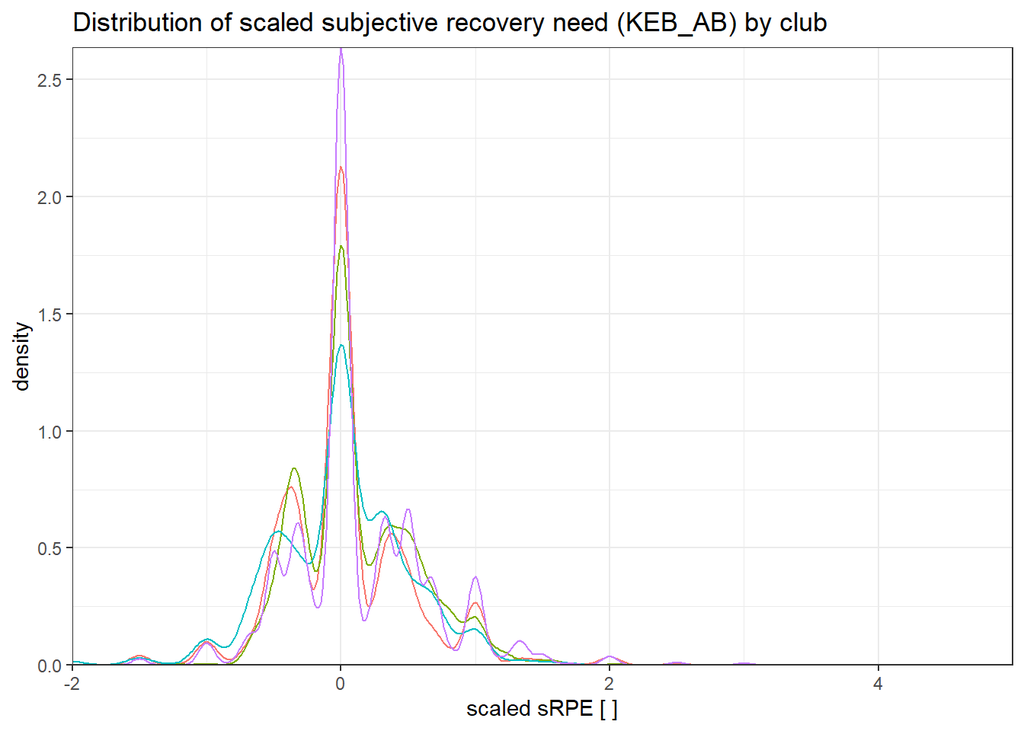

```r
ggplot(data, aes(x=KEB_AB_robust, color=Club_code)) + geom_density() + ggtitle("Distribution of scaled subjective recovery need (KEB_AB) by club") + theme(legend.position = "none") + xlab("scaled sRPE [ ]")+scale_x_continuous(expand = c(0,0))+scale_y_continuous(expand = c(0,0))+
  ggplot_theme+guides(color="none")
```

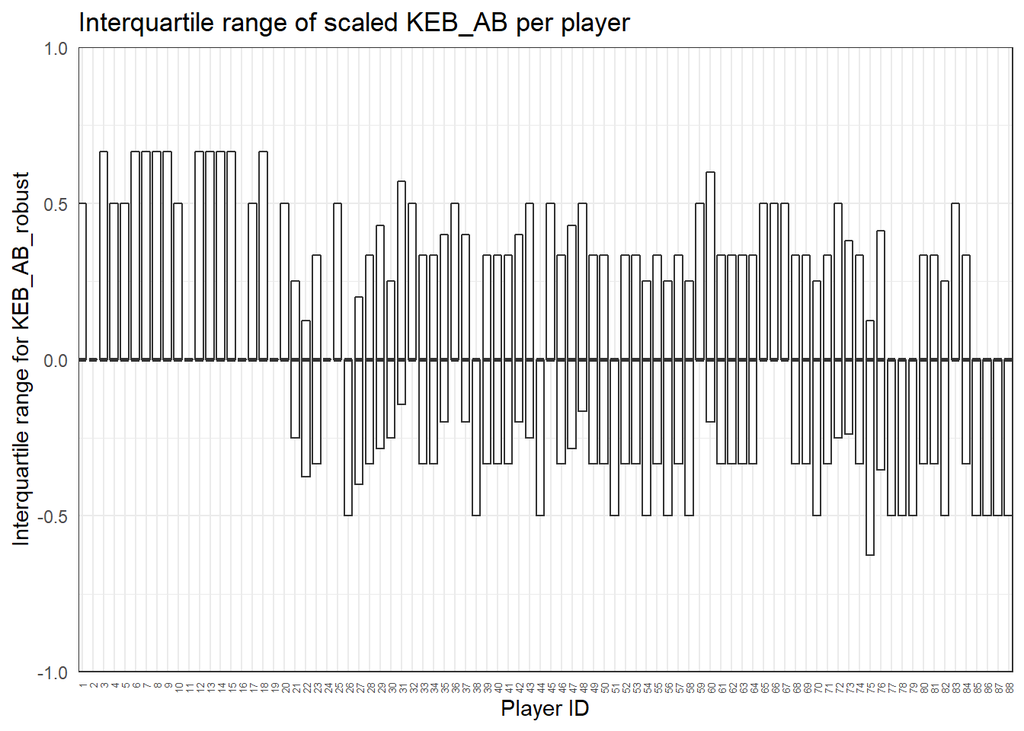

```r
ggplot(data, aes(x=ID_KEB, y=KEB_AB_robust)) + geom_boxplot(outlier.shape = NA, coef = 0) + ggtitle("Interquartile range of scaled KEB_AB per player") + xlab("Player ID") + ylab("Interquartile range for KEB_AB_robust")+ggplot_theme + theme(axis.ticks = element_blank(), axis.text.x = element_text(angle = 90, vjust = 0.5, hjust=1,size = 5)) + coord_cartesian(ylim = c(-1, 1))+scale_x_discrete(expand = c(0,0))+scale_y_continuous(expand = c(0,0))+
  guides(color="none")
```

### Additional feature: Time following return-to-play

In addition to the a-priori specified set of features, the time frame (4 weeks) following return to play is identified.

Note: The reason for the “unfit” period is not considered (not restricted to the follow-up of criterion injuries)

#### Calculate difference in Unfit status from the previous day

```r
# Define function for Unfit status on the previous day
trailing_day <- function(df){
  df$Unfit_prev <- runner(x = as.vector(df$Unfit), f = function(x) sum(x, na.rm = TRUE), k = 1, lag = 1)
  return(df)
}

order_date <- function(df){
  df <- arrange(df, ID, Date)
  return(df)
}

# Split the dataset according to ID
data_split <- split(data, data$ID)

# Apply function
data_split <- lapply(data_split, order_date)
data_split <- lapply(data_split, trailing_day)

# Unlist back to one df and adjust object type
data <- ldply(data_split, data.frame)
data$Unfit_prev <- as.logical(data$Unfit_prev)
data$Unfit_change <- xor(data$Unfit,data$Unfit_prev)

# Identify day of RTP (change from Unfit = 2 to Unfit = 1)
data$RTP <- !data$Unfit & data$Unfit_prev

table(data$RTP)
```

```
##
## FALSE  TRUE
## 17123    95
```

#### Identify timepoints within 4 weeks following return to play

```r
# Define function for trailing sum of RTP over past 4 weeks
trailing_RTP <- function(df){
  df$After_RTP <- runner(x = as.vector(df$RTP), f = function(x) sum(x, na.rm = TRUE), k = 28, lag = 1)
  return(df)
}

# Split the dataset according to ID
data_split <- split(data, data$ID)

# Apply function
data_split <- lapply(data_split, order_date)
data_split <- lapply(data_split, trailing_RTP)


# Unlist back to one df and set to logical
data <- ldply(data_split, data.frame)

data$After_RTP <- as.logical(data$After_RTP)

table(data$After_RTP)
```

```
##
## FALSE  TRUE
## 14866  2352
```

# Finalizing the curated dataset for the main analysis

```r
# Filter for relevant variables
data_analyse <- data %>% select(ID, Date, Day_in_study, Club_code, Inj_status, Unfit, After_RTP, Crit, TL_injury, Age, Pos_code, VV_days_c, VV_resid_age, Fat, IAT, Sprint_30, SIMS_score, SIMS_pain, Srpe, Source, Srpe_avg_7d, Srpe_7d_robust, KEB_AB, KEB_AB_robust, Source_KEB, Matchday, Training_time, Srpe_team_avg, Srpe_team_robust, Days_off, Reason, Injury_mechanism, Injury_date, Return_date, Victim)

save(data_analyse, file = "data_analyse.RData")
```